# Problem Set 8

Rebecca Xi

4/15/2020

## Question 1: Conduct exploratory data analysis

### 1A) Summary Statistics

Data summary

| Name | tibble$total_tweets |
| --- | --- |
| Number of rows | 4929 |
| Number of columns | 1 |
| _______________________ |  |
| Column type frequency: |  |
| numeric | 1 |
| ________________________ |  |
| Group variables | None |

**Variable type: numeric**

Data summary

| skim_variable | n_missing | complete_rate | mean | sd | p0 | p25 | p50 | p75 | p100 | hist |
| --- | --- | --- | --- | --- | --- | --- | --- | --- | --- | --- |
| data | 0 | 1 | 19.73 | 28.41 | 0 | 0 | 0 | 41 | 109 | ▇▁▂▁▁ |

| Name | tibble$approve |
| --- | --- |
| Number of rows | 4929 |
| Number of columns | 1 |
| _______________________ |  |
| Column type frequency: |  |
| numeric | 1 |
| ________________________ |  |
| Group variables | None |

**Variable type: numeric**

| skim_variable | n_missing | complete_rate | mean | sd | p0 | p25 | p50 | p75 | p100 | hist |
| --- | --- | --- | --- | --- | --- | --- | --- | --- | --- | --- |
| data | 0 | 1 | 41.36 | 4.08 | 23.9 | 38.1 | 41 | 44 | 59 | ▁▂▇▃▁ |

### 1B) Bivariate correlations

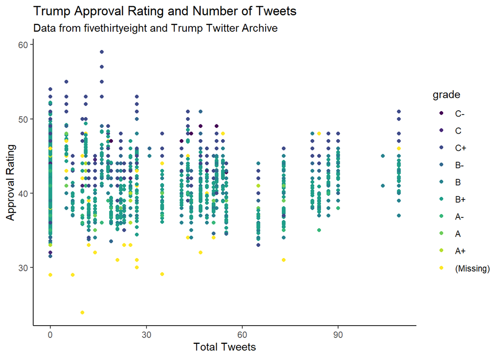

```
## # A tibble: 1 x 1
##      corr
##     <dbl>
## 1 -0.0262
```

There does not seem to be a strong relationship in either direction between tweet activity and approval ratings. This is reflected by the scatterplot.

## Question 2: Run a multivariate regression

### 2A) Using lm()

Effect of Number of Tweets and Poll Quality on Reported Approval Rating

Data from fivethirtyeight and Trump Tweet Archive

| Variable | Estimate | Lower bound | Upper bound |
| --- | --- | --- | --- |
| (Intercept) | 41.60335 | 41.46242 | 41.74428 |
| total_tweets | -0.00429 | -0.00826 | -0.00033 |
| high_q | -2.34720 | -2.79229 | -1.90211 |

### 2B) Interpreting results

The estimated average treatment effect of high_q, i.e. the effect on approval rating of changing the binary variable high_q from 0 to 1, is -2.34720. It seems that, taking into account the other explanatory variable total_tweets, there is an associated decrease of on average 2.34720 points in reported approval rating from switching from a low quality poll to a high quality poll.

A frequentist intrepretation says that there are true values of the linear model’s parameters and that the coefficients are the point estimates of these parameters, while a Bayesian interpretation treats the model parameters as probability distributions which are to be inferred from real data.

### 2C) Interaction Variables

Effect of Number of Tweets and Poll Quality on Reported Approval Rating

Data from fivethirtyeight and Trump Tweet Archive

| Variable | Estimate | Lower bound | Upper bound |
| --- | --- | --- | --- |
| (Intercept) | 41.62918 | 41.48684 | 41.77152 |
| total_tweets | -0.00559 | -0.00968 | -0.00149 |
| high_q | -2.70146 | -3.22772 | -2.17519 |
| total_tweets:high_q | 0.02053 | 0.00424 | 0.03683 |